# Bayesian Logistic Regression models and missingness - Application in Diabetes Probability Prediction

## Modeling

Bayesian data augmentation and Logistic regression Austin et al. (2021)

1. Priors - Bayesian augmentation stabilizes estimates via priors and provides finite, interpretable estimates and provides more reliable inferences.
   - Shrinkage is possible when including predictors (BMI, age, gender, race )
   - Encoding prior beliefs predicts estimates when data are sparse (Prior knowledge from literature suggests obesity is linked to diabetes)
2. Bayesian modeling plays nicely with multiple imputation or joint, propagating uncertainty instead of silently dropping cases.
3. Calculated Posterior and credible intervals for both coefficients and individual risk make clinical interpretation and shared decision-making models.
4. Bayesian logistic GLM gives an interpretable, survey-aware, uncertainty-quantified Diabetes risk model that’s robust to sparse subgroups and easy to update.
5. It is easy for an update, a new NHANES cycle can update the calculated posterior rather than refitting from scratch, developing a live risk model.
6. Bayesian gives full probability statements instead of only Odds Ratio (OR) with 94% probabilistic results (credible intervals), and not just p-values.

*Linear Regression equation:*

$$y_i = \beta_0 + \beta_1 X_1 +\varepsilon_i$$

**Comparision of multiple imputation and Bayesian data augmentation**

**Multiple imputation**

**Bayesian data augmentation**

- frequentist approach and requires no priors, and has moderate flexibility
- performs missing data imputation and regression model fitting simultaneously
- Markov Chain Monte Carlo (MCMC) draws samples from the joint posterior of regression parameters, missing values and provide complete datasets by extracting posterior means, credible intervals, and probabilities
- handles missing values first by imputation, performs regression analysis, pools results
- performed on the data with missingness
- shrink extreme estimates back toward plausible values
- propagate uncertainty added after analysis (pooling).
- handles uncertainty in missing values fully propagated through the model, naturally handles small or sparse datasets and separation problems.

**Diagnostics performed before regression analysis**

1. Modeling assumption check
2. Correlation matrix, Cook’s distance, influential points
3. Model plot

```r
# MLR on imputed data
# assumption check (# for correlation # )
# correlation matrix

m_imp1 <- glm(diab ~ age + gender + race + BMI_cat,
          data = Imputed_data1,
          family = binomial)
m_imp1
```

```
Call:  glm(formula = diab ~ age + gender + race + BMI_cat, family = binomial,
    data = Imputed_data1)

Coefficients:
                            (Intercept)
                              -0.761926
                                    age
                              -0.004728
                           genderFemale
                              -0.092730
                     raceOther Hispanic
                              -0.154250
                 raceNon-Hispanic White
                              -0.212663
                 raceNon-Hispanic Black
                              -0.055537
raceOther Race - Including Multi-Racial
                              -0.109388
                   BMI_catNormal weight
                               0.024339
                      BMI_catOverweight
                               0.071544
                           BMI_catObese
                               0.020287

Degrees of Freedom: 9812 Total (i.e. Null);  9803 Residual
Null Deviance:      11270
Residual Deviance: 11220    AIC: 11240
```

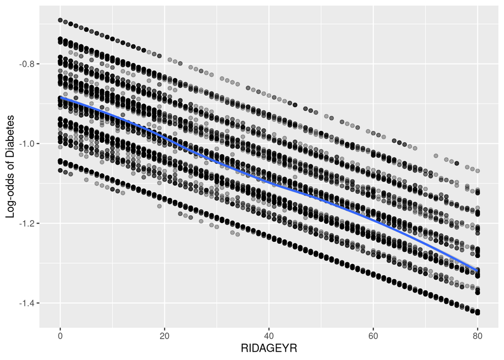

```r
# Get the predicted logit
Imputed_data1$logit <- predict(m_imp1, type = "link")  # 'link' gives log-odds

# Plot BMI vs logit

plot_imp1 <- ggplot(Imputed_data1, aes(x = age, y = logit)) +
  geom_point(alpha = 0.3) +
  geom_smooth(method = "loess") +
  labs(x = "RIDAGEYR", y = "Log-odds of Diabetes")

 plot_imp1
```

```r
# Calculate fitted values and residuals from the final model
    fitted_imputed1 <- fitted(m_imp1)
    residual_imputed1 <- residuals(m_imp1)


#Implication for modeling:

# collinearity check #

library(car)
    vif(m_imp1)  # VIF > 5 or 10 indicates multicollinearity
```

```
            GVIF Df GVIF^(1/(2*Df))
age     1.108163  1        1.052693
gender  1.002032  1        1.001015
race    1.040913  4        1.005025
BMI_cat 1.078206  3        1.012629
```

```r
# Check for influential points and outliers #
library(broom)
    influence_m_imp1 <- broom::augment(m_imp1)
    influence_m_imp1
```

```
# A tibble: 9,813 × 11
   diab    age gender race        BMI_cat .fitted .resid     .hat .sigma .cooksd
   <fct> <dbl> <fct>  <fct>       <fct>     <dbl>  <dbl>    <dbl>  <dbl>   <dbl>
 1 Yes      69 Male   Non-Hispan… Obese    -1.12  -0.750 0.001000   1.07 3.26e-5
 2 Yes      54 Male   Non-Hispan… Normal…  -1.21  -0.724 0.000549   1.07 1.65e-5
 3 No       72 Male   Non-Hispan… Overwe…  -1.24   1.73  0.000973   1.07 3.38e-4
 4 Yes       9 Male   Non-Hispan… Normal…  -0.993 -0.794 0.000593   1.07 2.20e-5
 5 Yes      73 Female Non-Hispan… Overwe…  -1.34  -0.682 0.000923   1.07 2.42e-5
 6 No       56 Male   Mexican Am… Normal…  -1.00   1.62  0.00105    1.07 2.88e-4
 7 Yes       0 Male   Non-Hispan… Normal…  -0.950 -0.809 0.000701   1.07 2.71e-5
 8 Yes      61 Female Non-Hispan… Overwe…  -1.28  -0.699 0.000835   1.07 2.32e-5
 9 Yes      56 Female Non-Hispan… Obese    -1.31  -0.691 0.000614   1.07 1.66e-5
10 No       65 Male   Non-Hispan… Normal…  -1.26   1.74  0.000646   1.07 2.27e-4
# ℹ 9,803 more rows
# ℹ 1 more variable: .std.resid <dbl>
```

```r
    Imputed_data1 <- Imputed_data1 %>%
    mutate(outlier =  if_else(abs(rstandard(m_imp1))>2.5, "Suspected", "Not Suspected"))

    Imputed_data1 %>% count(outlier)
```

```
        outlier    n
1 Not Suspected 9813
```

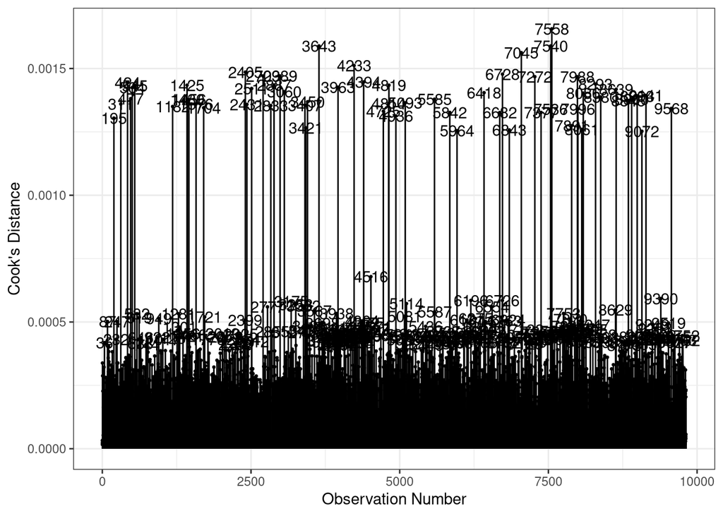

```r
    cooks(m_imp1)
```

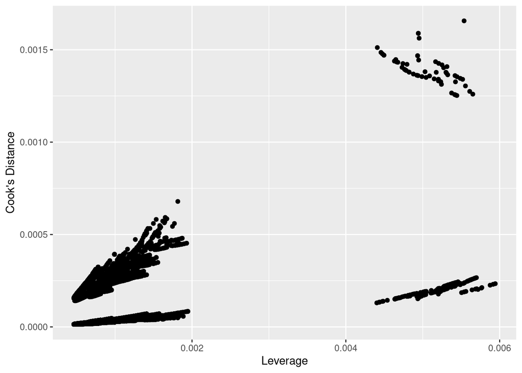

```r
# Visualization
ggplot(influence_m_imp1, aes(x = .hat, y = .cooksd)) +
  geom_point() +
  labs(x = "Leverage", y = "Cook's Distance")
```

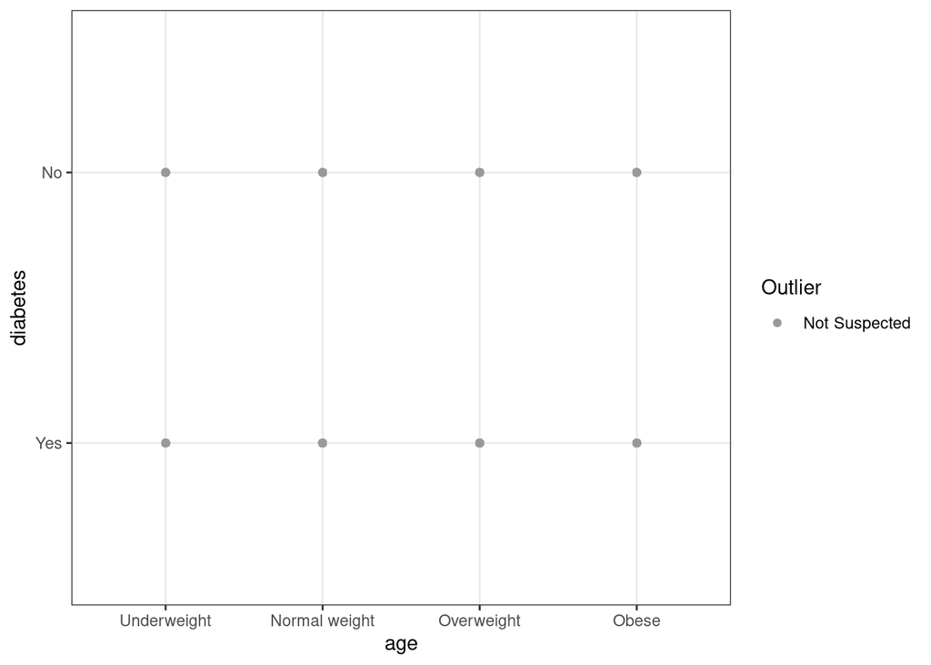

```r
Imputed_data1 %>% ggplot(aes(x = BMI_cat, y = diab, color = outlier)) +
  geom_point() +
  scale_color_manual(values = c("#999999", "#000000")) +
  labs(x = "age", y = "diabetes", color = "Outlier") +
  theme_bw()
```

```r
# transform response variable to codes

Imputed_data1$diab_num <- ifelse(Imputed_data1$diab == "Yes", 1, 0)

library(ResourceSelection)
hoslem.test(Imputed_data1$diab_num, fitted(m_imp1))
```

```
    Hosmer and Lemeshow goodness of fit (GOF) test

data:  Imputed_data1$diab_num, fitted(m_imp1)
X-squared = 12190, df = 8, p-value < 2.2e-16
```

```r
summary(m_imp1)
```

```
Call:
glm(formula = diab ~ age + gender + race + BMI_cat, family = binomial,
    data = Imputed_data1)

Coefficients:
                                         Estimate Std. Error z value Pr(>|z|)
(Intercept)                             -0.761926   0.162425  -4.691 2.72e-06
age                                     -0.004728   0.001011  -4.678 2.89e-06
genderFemale                            -0.092730   0.046133  -2.010  0.04442
raceOther Hispanic                      -0.154250   0.092549  -1.667  0.09558
raceNon-Hispanic White                  -0.212663   0.067746  -3.139  0.00169
raceNon-Hispanic Black                  -0.055537   0.072128  -0.770  0.44131
raceOther Race - Including Multi-Racial -0.109388   0.080345  -1.361  0.17336
BMI_catNormal weight                     0.024339   0.156361   0.156  0.87630
BMI_catOverweight                        0.071544   0.162658   0.440  0.66005
BMI_catObese                             0.020287   0.161137   0.126  0.89981

(Intercept)                             ***
age                                     ***
genderFemale                            *
raceOther Hispanic                      .
raceNon-Hispanic White                  **
raceNon-Hispanic Black
raceOther Race - Including Multi-Racial
BMI_catNormal weight
BMI_catOverweight
BMI_catObese
---
Signif. codes:  0 '***' 0.001 '**' 0.01 '*' 0.05 '.' 0.1 ' ' 1

(Dispersion parameter for binomial family taken to be 1)

    Null deviance: 11267  on 9812  degrees of freedom
Residual deviance: 11219  on 9803  degrees of freedom
AIC: 11239

Number of Fisher Scoring iterations: 4
```